# PM2.5

## Introduction

#### Beijing PM2.5 Data Set

#### Data Set Information:

#### The date time period is between Jan 1st, 2010 to Dec 31st, 2014

```
## [1] 43824    13
```

```
## [1] 41543    16
```

```
##    year pm2.5 DEWP TEMP PRES cbwd  Iws Is Ir   Y sin_month cos_month
## 26 2010   148  -15   -4 1020   SE 2.68  0  0 129       0.5 0.8660254
## 27 2010   159  -11   -5 1021   SE 3.57  0  0 148       0.5 0.8660254
## 28 2010   181   -7   -5 1022   SE 5.36  1  0 159       0.5 0.8660254
## 29 2010   138   -7   -5 1022   SE 6.25  2  0 181       0.5 0.8660254
## 30 2010   109   -7   -6 1022   SE 7.14  3  0 138       0.5 0.8660254
## 31 2010   105   -7   -6 1023   SE 8.93  4  0 109       0.5 0.8660254
##       sin_day   cos_day  sin_hour     cos_hour
## 26 0.03442161 0.9994074 0.2588190 9.659258e-01
## 27 0.03442161 0.9994074 0.5000000 8.660254e-01
## 28 0.03442161 0.9994074 0.7071068 7.071068e-01
## 29 0.03442161 0.9994074 0.8660254 5.000000e-01
## 30 0.03442161 0.9994074 0.9659258 2.588190e-01
## 31 0.03442161 0.9994074 1.0000000 6.123234e-17
```

```
## dummies-1.5.6 provided by Decision Patterns
```

## Descriptive analysis

### Response variable : **pm2.5**

In this data set, the response variable takes value between $0$ and $ 994$ with average value of $98.6$, variance of $8470.619$ and other statistical descriptions as shown in the below table.

```
##    Min. 1st Qu.  Median    Mean 3rd Qu.    Max.
##     0.0    29.0    72.0    98.6   137.0   994.0
```

This variable appears not to follow the Guassian distribution by immediately look at its distribution in the below graphic.

Moreover, depending on the Boxplot, we can see that there are some weired data points which will be considered as another problem for our regression. However, we will try to see the effect of those outlier in our model later.

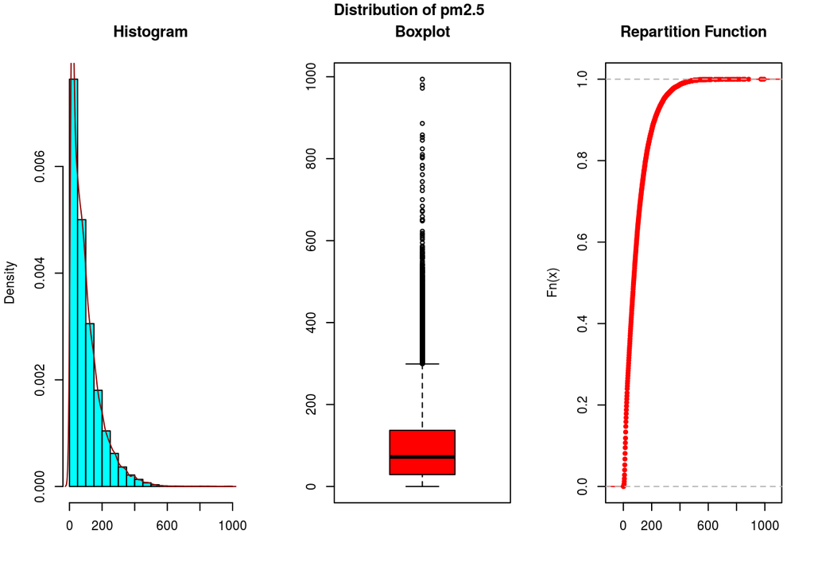

### Predictors and correlation

Firstly there are 12 predictors in our data set and one of them are categorical variable.After that, we transformed time variables into two dimensions and the categorical variable into binary. And we also add variable pm2.5 at time $t_(n-1)$. So that we have 18 preditors. In this part, we will focus on two important kind of correlations. One is between independent variables, and another one is between independent and response variable . Since there are two kinds of predictors in our data set, we will look at those relationships separately.

[figure not shown]

## Construction Multilinear Models

### Linear models

```
##
## Call:
## lm(formula = "train_Y~.", data = as.data.frame(cbind(train_X,
##     train_Y)))
##
## Residuals:
##     Min      1Q  Median      3Q     Max
## -522.37   -7.46    0.20    7.81  638.33
##
## Coefficients: (1 not defined because of singularities)
##                                                         Estimate
## (Intercept)                                           139.710842
## year                                                    0.019772
## DEWP                                                    0.522223
## TEMP                                                   -0.515058
## PRES                                                   -0.162729
## Iws                                                     0.005943
## Is                                                     -0.585872
## Ir                                                     -0.803898
## Y                                                       0.933798
## sin_month                                              -0.372131
## cos_month                                               0.364964
## sin_day                                                 2.398912
## cos_day                                                 4.655146
## sin_hour                                               -3.606432
## cos_hour                                               -0.103608
## `/home/hao/ensiieS3/MRR/Projet/Project/PM2.5-2.Rmdcv`   1.768414
## `/home/hao/ensiieS3/MRR/Projet/Project/PM2.5-2.RmdNE`  -2.398808
## `/home/hao/ensiieS3/MRR/Projet/Project/PM2.5-2.RmdNW`  -6.828758
## `/home/hao/ensiieS3/MRR/Projet/Project/PM2.5-2.RmdSE`         NA
##                                                       Std. Error t value
## (Intercept)                                           191.858426   0.728
## year                                                    0.094856   0.208
## DEWP                                                    0.030898  16.902
## TEMP                                                    0.039359 -13.086
## PRES                                                    0.026420  -6.159
## Iws                                                     0.003041   1.954
## Is                                                      0.180615  -3.244
## Ir                                                      0.095433  -8.424
## Y                                                       0.001884 495.688
```

[output cut: 21 more lines]

```
## cos_month                                              0.76958
## sin_day                                                0.05711 .
## cos_day                                                0.00164 **
## sin_hour                                               < 2e-16 ***
## cos_hour                                               0.64209
## `/home/hao/ensiieS3/MRR/Projet/Project/PM2.5-2.Rmdcv` 3.37e-06 ***
## `/home/hao/ensiieS3/MRR/Projet/Project/PM2.5-2.RmdNE` 4.46e-07 ***
## `/home/hao/ensiieS3/MRR/Projet/Project/PM2.5-2.RmdNW`  < 2e-16 ***
## `/home/hao/ensiieS3/MRR/Projet/Project/PM2.5-2.RmdSE`       NA
## ---
## Signif. codes:  0 '***' 0.001 '**' 0.01 '*' 0.05 '.' 0.1 ' ' 1
##
## Residual standard error: 23.57 on 31982 degrees of freedom
## Multiple R-squared:  0.934,  Adjusted R-squared:  0.9339
## F-statistic: 2.661e+04 on 17 and 31982 DF,  p-value: < 2.2e-16
```

```
## [1] 555.1366
```

This linear regression model gets a high R-squared. It should be a good model and it performs quite well on test set because we added variable of pm2.5 at previous time.

### Model selection contructed by stepwise (Forward/Backward)

This algorithm considers all models starting from null model (using only intercept) to more complex model with more variables called Forward regression. Another regression starts from full model (using all variables) to more simple model with less variables called Backward regression. In this case, we will use stepwise regression with both directions and we measure each model using two criteria AIC and BIC. We name those two models with best value of AIC and BIC, step.AIC and step.BIC respectively.

```
## Start:  AIC=202250.9
## train_Y ~ year + DEWP + TEMP + PRES + Iws + Is + Ir + Y + sin_month +
##     cos_month + sin_day + cos_day + sin_hour + cos_hour + `/home/hao/ensiieS3/MRR/Projet/Project/PM2.5-2.Rmdcv` +
##     `/home/hao/ensiieS3/MRR/Projet/Project/PM2.5-2.RmdNE` + `/home/hao/ensiieS3/MRR/Projet/Project/PM2.5-2.RmdNW` +
##     `/home/hao/ensiieS3/MRR/Projet/Project/PM2.5-2.RmdSE`
##
##
## Step:  AIC=202250.9
## train_Y ~ year + DEWP + TEMP + PRES + Iws + Is + Ir + Y + sin_month +
##     cos_month + sin_day + cos_day + sin_hour + cos_hour + `/home/hao/ensiieS3/MRR/Projet/Project/PM2.5-2.Rmdcv` +
##     `/home/hao/ensiieS3/MRR/Projet/Project/PM2.5-2.RmdNE` + `/home/hao/ensiieS3/MRR/Projet/Project/PM2.5-2.RmdNW`
##
##                                                         Df Sum of Sq
## - year                                                   1        24
## - cos_month                                              1        48
## - sin_month                                              1        50
## - cos_hour                                               1       120
## <none>
## - sin_day                                                1      2011
## - Iws                                                    1      2122
## - cos_day                                                1      5509
## - Is                                                     1      5844
## - `/home/hao/ensiieS3/MRR/Projet/Project/PM2.5-2.Rmdcv`  1     11997
## - `/home/hao/ensiieS3/MRR/Projet/Project/PM2.5-2.RmdNE`  1     14162
## - PRES                                                   1     21073
## - Ir                                                     1     39414
## - TEMP                                                   1     95121
## - sin_hour                                               1    134030
## - DEWP                                                   1    158673
## - `/home/hao/ensiieS3/MRR/Projet/Project/PM2.5-2.RmdNW`  1    176366
## - Y                                                      1 136477440
##                                                               RSS    AIC
## - year                                                   17764395 202249
## - cos_month                                              17764418 202249
## - sin_month                                              17764421 202249
## - cos_hour                                               17764491 202249
## <none>                                                   17764371 202251
## - sin_day                                                17766381 202252
## - Iws                                                    17766492 202253
## - cos_day                                                17769880 202259
```

[output cut: 151 more lines]

```
##                                                               RSS    AIC
## <none>                                                   17764603 202243
## - Iws                                                    17766684 202245
## - Is                                                     17770446 202252
## - `/home/hao/ensiieS3/MRR/Projet/Project/PM2.5-2.Rmdcv`  17776809 202263
## - `/home/hao/ensiieS3/MRR/Projet/Project/PM2.5-2.RmdNE`  17778665 202267
## - PRES                                                   17785722 202279
## - sin_day                                                17787527 202283
## - cos_day                                                17790624 202288
## - Ir                                                     17804014 202312
## - TEMP                                                   17895640 202476
## - sin_hour                                               17907783 202498
## - DEWP                                                   17924499 202528
## - `/home/hao/ensiieS3/MRR/Projet/Project/PM2.5-2.RmdNW`  17941157 202558
## - Y                                                     154423615 271441
```

```
##
## Call:
## lm(formula = train_Y ~ DEWP + TEMP + PRES + Iws + Is + Ir + Y +
##     sin_day + cos_day + sin_hour + `/home/hao/ensiieS3/MRR/Projet/Project/PM2.5-2.Rmdcv` +
##     `/home/hao/ensiieS3/MRR/Projet/Project/PM2.5-2.RmdNE` + `/home/hao/ensiieS3/MRR/Projet/Project/PM2.5-2.RmdNW`,
##     data = as.data.frame(cbind(train_X, train_Y)))
##
## Residuals:
##     Min      1Q  Median      3Q     Max
## -522.45   -7.47    0.20    7.81  638.24
##
## Coefficients:
##                                                         Estimate
## (Intercept)                                           178.066295
## DEWP                                                    0.521687
## TEMP                                                   -0.504362
## PRES                                                   -0.161457
## Iws                                                     0.005872
## Is                                                     -0.584248
## Ir                                                     -0.801294
## Y                                                       0.933767
## sin_day                                                 1.983089
## cos_day                                                 5.046702
## sin_hour                                               -3.575069
## `/home/hao/ensiieS3/MRR/Projet/Project/PM2.5-2.Rmdcv`   1.781028
## `/home/hao/ensiieS3/MRR/Projet/Project/PM2.5-2.RmdNE`  -2.389131
## `/home/hao/ensiieS3/MRR/Projet/Project/PM2.5-2.RmdNW`  -6.817364
##                                                       Std. Error t value
## (Intercept)                                            26.782399   6.649
## DEWP                                                    0.030746  16.968
## TEMP                                                    0.032836 -15.360
## PRES                                                    0.026183  -6.167
## Iws                                                     0.003034   1.936
## Is                                                      0.180118  -3.244
## Ir                                                      0.095122  -8.424
## Y                                                       0.001882 496.045
## sin_day                                                 0.308666   6.425
## cos_day                                                 0.737302   6.845
## sin_hour                                                0.222659 -16.056
## `/home/hao/ensiieS3/MRR/Projet/Project/PM2.5-2.Rmdcv`   0.379913   4.688
```

[output cut: 8 more lines]

```
## Is                                                     0.00118 **
## Ir                                                     < 2e-16 ***
## Y                                                      < 2e-16 ***
## sin_day                                               1.34e-10 ***
## cos_day                                               7.79e-12 ***
## sin_hour                                               < 2e-16 ***
## `/home/hao/ensiieS3/MRR/Projet/Project/PM2.5-2.Rmdcv` 2.77e-06 ***
## `/home/hao/ensiieS3/MRR/Projet/Project/PM2.5-2.RmdNE` 4.88e-07 ***
## `/home/hao/ensiieS3/MRR/Projet/Project/PM2.5-2.RmdNW`  < 2e-16 ***
## ---
## Signif. codes:  0 '***' 0.001 '**' 0.01 '*' 0.05 '.' 0.1 ' ' 1
##
## Residual standard error: 23.57 on 31986 degrees of freedom
## Multiple R-squared:  0.934,  Adjusted R-squared:  0.9339
## F-statistic: 3.48e+04 on 13 and 31986 DF,  p-value: < 2.2e-16
```

```
## Start:  AIC=202250.9
## train_Y ~ year + DEWP + TEMP + PRES + Iws + Is + Ir + Y + sin_month +
##     cos_month + sin_day + cos_day + sin_hour + cos_hour + `/home/hao/ensiieS3/MRR/Projet/Project/PM2.5-2.Rmdcv` +
##     `/home/hao/ensiieS3/MRR/Projet/Project/PM2.5-2.RmdNE` + `/home/hao/ensiieS3/MRR/Projet/Project/PM2.5-2.RmdNW` +
##     `/home/hao/ensiieS3/MRR/Projet/Project/PM2.5-2.RmdSE`
```

```
##
## Call:
## lm(formula = train_Y ~ year + DEWP + TEMP + PRES + Iws + Is +
##     Ir + Y + sin_month + cos_month + sin_day + cos_day + sin_hour +
##     cos_hour + `/home/hao/ensiieS3/MRR/Projet/Project/PM2.5-2.Rmdcv` +
##     `/home/hao/ensiieS3/MRR/Projet/Project/PM2.5-2.RmdNE` + `/home/hao/ensiieS3/MRR/Projet/Project/PM2.5-2.RmdNW` +
##     `/home/hao/ensiieS3/MRR/Projet/Project/PM2.5-2.RmdSE`, data = as.data.frame(cbind(train_X,
##     train_Y)))
##
## Residuals:
##     Min      1Q  Median      3Q     Max
## -522.37   -7.46    0.20    7.81  638.33
##
## Coefficients: (1 not defined because of singularities)
##                                                         Estimate
## (Intercept)                                           139.710842
## year                                                    0.019772
## DEWP                                                    0.522223
## TEMP                                                   -0.515058
## PRES                                                   -0.162729
## Iws                                                     0.005943
## Is                                                     -0.585872
## Ir                                                     -0.803898
## Y                                                       0.933798
## sin_month                                              -0.372131
## cos_month                                               0.364964
## sin_day                                                 2.398912
## cos_day                                                 4.655146
## sin_hour                                               -3.606432
## cos_hour                                               -0.103608
## `/home/hao/ensiieS3/MRR/Projet/Project/PM2.5-2.Rmdcv`   1.768414
## `/home/hao/ensiieS3/MRR/Projet/Project/PM2.5-2.RmdNE`  -2.398808
## `/home/hao/ensiieS3/MRR/Projet/Project/PM2.5-2.RmdNW`  -6.828758
## `/home/hao/ensiieS3/MRR/Projet/Project/PM2.5-2.RmdSE`         NA
##                                                       Std. Error t value
## (Intercept)                                           191.858426   0.728
## year                                                    0.094856   0.208
## DEWP                                                    0.030898  16.902
## TEMP                                                    0.039359 -13.086
## PRES                                                    0.026420  -6.159
```

[output cut: 25 more lines]

```
## cos_month                                              0.76958
## sin_day                                                0.05711 .
## cos_day                                                0.00164 **
## sin_hour                                               < 2e-16 ***
## cos_hour                                               0.64209
## `/home/hao/ensiieS3/MRR/Projet/Project/PM2.5-2.Rmdcv` 3.37e-06 ***
## `/home/hao/ensiieS3/MRR/Projet/Project/PM2.5-2.RmdNE` 4.46e-07 ***
## `/home/hao/ensiieS3/MRR/Projet/Project/PM2.5-2.RmdNW`  < 2e-16 ***
## `/home/hao/ensiieS3/MRR/Projet/Project/PM2.5-2.RmdSE`       NA
## ---
## Signif. codes:  0 '***' 0.001 '**' 0.01 '*' 0.05 '.' 0.1 ' ' 1
##
## Residual standard error: 23.57 on 31982 degrees of freedom
## Multiple R-squared:  0.934,  Adjusted R-squared:  0.9339
## F-statistic: 2.661e+04 on 17 and 31982 DF,  p-value: < 2.2e-16
```

```
## [1]     14.0 202363.6
```

```
## [1]     18.0 202405.6
```

```
## train_Y ~ DEWP + TEMP + PRES + Iws + Is + Ir + Y + sin_day +
##     cos_day + sin_hour + `/home/hao/ensiieS3/MRR/Projet/Project/PM2.5-2.Rmdcv` +
##     `/home/hao/ensiieS3/MRR/Projet/Project/PM2.5-2.RmdNE` + `/home/hao/ensiieS3/MRR/Projet/Project/PM2.5-2.RmdNW`
## <environment: 0x48c4258>
```

```
## [1] 555.1438
```

```
## train_Y ~ year + DEWP + TEMP + PRES + Iws + Is + Ir + Y + sin_month +
##     cos_month + sin_day + cos_day + sin_hour + cos_hour + `/home/hao/ensiieS3/MRR/Projet/Project/PM2.5-2.Rmdcv` +
##     `/home/hao/ensiieS3/MRR/Projet/Project/PM2.5-2.RmdNE` + `/home/hao/ensiieS3/MRR/Projet/Project/PM2.5-2.RmdNW` +
##     `/home/hao/ensiieS3/MRR/Projet/Project/PM2.5-2.RmdSE`
## <environment: 0x48c4258>
```

```
## [1] 555.1366
```

```
## [1] 528.3827
```

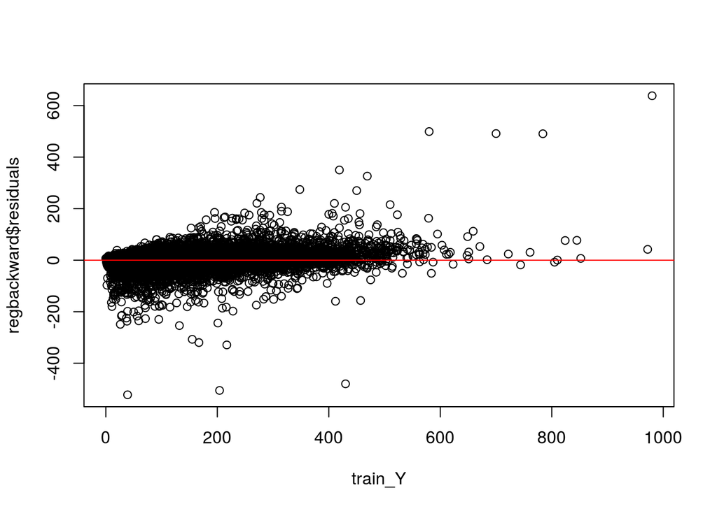

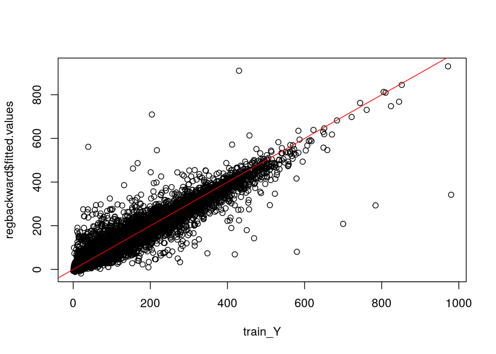

```
## [1] 555.1438
```

We check for the diagnostic of these two models. These models get a high R-square and their mean square errors are a bit larger than normal linear regression model. The residuals seem to be symmetric in the graphic above. It appears to be good models.

## Penalisation Regression

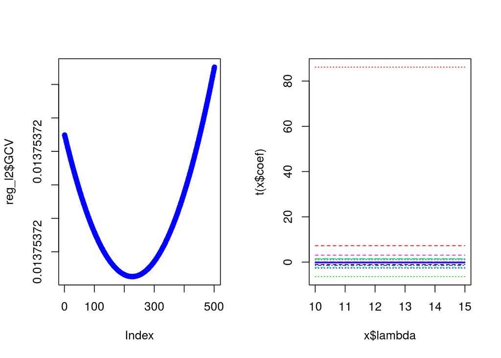

```
##        Length Class  Mode
## coef   9018   -none- numeric
## scales   18   -none- numeric
## Inter     1   -none- numeric
## lambda  501   -none- numeric
## ym        1   -none- numeric
## xm       18   -none- numeric
## GCV     501   -none- numeric
## kHKB      1   -none- numeric
## kLW       1   -none- numeric
```

```
## [1] 138.3662 138.3638 138.3613 138.3588 138.3563
```

```
## $names
## [1] "coef"   "scales" "Inter"  "lambda" "ym"     "xm"     "GCV"    "kHKB"
## [9] "kLW"
##
## $class
## [1] "ridgelm"
```

```
## modified HKB estimator is 3.51033e-24
## modified L-W estimator is 1.109211
## smallest value of GCV  at 12.25
```

```
##        Length Class  Mode
## coef   18     -none- numeric
## scales 18     -none- numeric
## Inter   1     -none- numeric
## lambda  1     -none- numeric
## ym      1     -none- numeric
## xm     18     -none- numeric
## GCV     1     -none- numeric
## kHKB    1     -none- numeric
## kLW     1     -none- numeric
```

```
##
##                                         137.682292038
##                                                  year
##                                           0.007599198
##                                                  DEWP
##                                           0.502416501
##                                                  TEMP
##                                          -0.525515800
##                                                  PRES
##                                          -0.138718001
##                                                   Iws
##                                           0.005787816
##                                                    Is
##                                          -0.576733572
##                                                    Ir
##                                          -0.763591272
##                                                     Y
##                                           0.936800885
##                                             sin_month
##                                          -0.260930257
##                                             cos_month
##                                          -0.136733525
##                                               sin_day
##                                           1.931512469
##                                               cos_day
##                                           4.324031869
##                                              sin_hour
##                                          -3.698132939
##                                              cos_hour
##                                          -0.168381011
## `/home/hao/ensiieS3/MRR/Projet/Project/PM2.5-2.Rmdcv`
##                                           3.628881655
## `/home/hao/ensiieS3/MRR/Projet/Project/PM2.5-2.RmdNE`
##                                          -0.624754009
## `/home/hao/ensiieS3/MRR/Projet/Project/PM2.5-2.RmdNW`
##                                          -4.798563467
## `/home/hao/ensiieS3/MRR/Projet/Project/PM2.5-2.RmdSE`
##                                           2.210954575
```

```
## [1] 555.2264
```

### Lasso Regression

It is similar to the Ridge regression. The difference is in the LASSO regression we constrain the variance of estimator using $\|.\|_1$. Because of the nature of this norm, it puts some variables to be 0 and the remaining variables are considered as significant for our model.
$$\hat{\beta}^{lasso}=arg \displaystyle\min_\beta\|Y-X\beta\|_{2}^2+\lambda|\beta\|_1$$

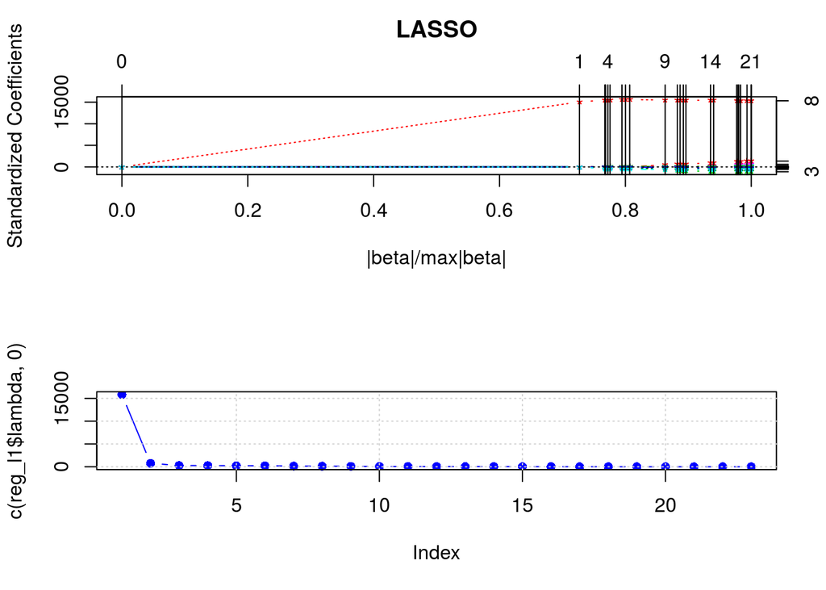

```
##             year      DEWP         TEMP        PRES         Iws
##  [1,] 0.00000000 0.0000000  0.000000000  0.00000000 0.000000000
##  [2,] 0.00000000 0.0000000  0.000000000  0.00000000 0.000000000
##  [3,] 0.00000000 0.0000000  0.000000000  0.00000000 0.000000000
##  [4,] 0.00000000 0.0000000  0.000000000  0.00000000 0.000000000
##  [5,] 0.00000000 0.0000000  0.000000000  0.00000000 0.000000000
##  [6,] 0.00000000 0.0000000 -0.009124809  0.00000000 0.000000000
##  [7,] 0.00000000 0.0000000 -0.051799000  0.00000000 0.000000000
##  [8,] 0.00000000 0.0000000 -0.063744105  0.00000000 0.000000000
##  [9,] 0.00000000 0.0000000 -0.076179404  0.00000000 0.000000000
## [10,] 0.00000000 0.1852619 -0.302650249  0.00000000 0.000000000
## [11,] 0.00000000 0.2276388 -0.384051603 -0.03886921 0.000000000
## [12,] 0.00000000 0.2387297 -0.401268500 -0.04570391 0.000000000
## [13,] 0.00000000 0.2510970 -0.420260486 -0.05283452 0.000000000
## [14,] 0.00000000 0.2606469 -0.434634873 -0.05830523 0.000000000
```

[output cut: 153 more lines]

```
##         Y
## 0.9035907
```

```
## [1] 1
```

```
## [1] 18
```

```
## [1] 555.1405
```

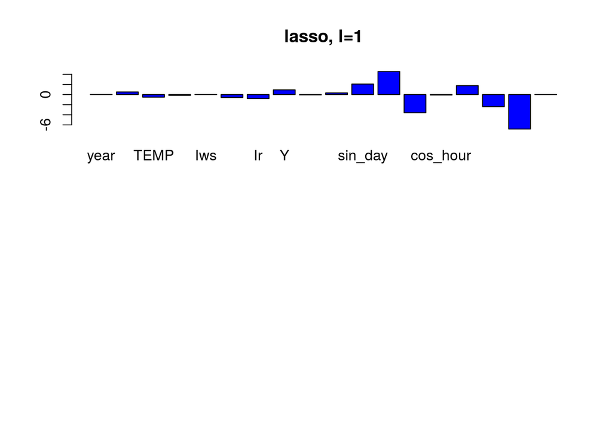

## Elastic net regularization

Elastic net is a hybrid approach that blends both penalization of the L2 and L1 norms. Ridge and LASSO are particular cases of Elastic net.

$$\hat{\beta}^{elas}=arg \displaystyle\min_\beta\|Y-X\beta\|_{2}^2+\lambda((1-\alpha)\|\beta\|_2^2+\alpha\|\beta\|_1)$$

We consider the following cases with different values of $\alpha\in\{0.05,0.1,...,0.95\}$. The following table is a particular case of Elastic net we obtained.

```
##         cvm lambda.1se alpha
## 1  577.9235   5.038295  0.05
## 2  582.2333   5.302564  0.10
## 3  589.0794   5.628788  0.15
## 4  576.4394   3.846556  0.20
## 5  585.0034   4.464556  0.25
## 6  587.2141   4.481311  0.30
## 7  575.1554   2.905669  0.35
## 8  589.2027   4.443022  0.40
## 9  571.1436   2.059196  0.45
## 10 577.2637   2.688787  0.50
## 11 584.1260   3.546335  0.55
## 12 582.2494   3.250808  0.60
## 13 576.4532   2.269954  0.65
## 14 581.9259   3.058078  0.70
## 15 585.9332   3.437901  0.75
## 16 580.3143   2.675818  0.80
## 17 581.6387   2.763959  0.85
## 18 592.2573   3.787252  0.90
## 19 580.0906   2.473016  0.95
```

```
##        cvm lambda.1se alpha
## 9 571.1436   2.059196  0.45
```

```
## 19 x 1 sparse Matrix of class "dgCMatrix"
##                                                              s0
## (Intercept)                                          8.62998536
## year                                                 .
## DEWP                                                 .
## TEMP                                                -0.04829279
## PRES                                                 .
## Iws                                                  .
## Is                                                   .
## Ir                                                   .
## Y                                                    0.93595833
## sin_month                                            .
## cos_month                                            .
## sin_day                                              .
## cos_day                                              .
## sin_hour                                            -0.82844404
## cos_hour                                             0.38863039
## /home/hao/ensiieS3/MRR/Projet/Project/PM2.5-2.Rmdcv  1.13955939
## /home/hao/ensiieS3/MRR/Projet/Project/PM2.5-2.RmdNE  .
## /home/hao/ensiieS3/MRR/Projet/Project/PM2.5-2.RmdNW -6.15450540
## /home/hao/ensiieS3/MRR/Projet/Project/PM2.5-2.RmdSE  .
```

```
## [1] 570.5857
```

The mean square error of this regularization gets a bit larger than ridge and lasso. Some coefficients are equal to 0(it means we can use less variables). It seems to be good model.